# Estudio estadístico sobre teleorientación psicológica dirigido a usuarios de Óyeme mayores de 18 años que requieran atención para la salud mental debido a la pandemia atravesada

02 Mayo, 2023

[figure not shown]

## Análisis de la teleorientación sobre los usuarios de “Óyeme”.

### Introducción

##### Importancia y Justicación

Durante la pandemia del Covid-19 han ido ocurriendo múltiples problemas que han afectado al bienestar de la población en general. Uno de los más comunes en estas situaciones son los que afectan a la salud mental. Esto ha ocasionado que los casos de estrés, depresión y ansiedad hayan aumentado los últimos meses. El distanciamiento social junto a la ausencia de comunicación interpersonal son uno de los factores que más han vulnerado estas condiciones mentales. Además, la crisis sanitaria tampoco ha permitido que las personas continúen con las sesiones psicológicas presenciales, lo que llevó a buscar alternativas que garanticen la seguridad de las personas. Por ello, nace la tele-orientación psicológica para contrarrestar los efectos colaterales del Covid-19. Este método es una de las nuevas alternativas propuestas en el mercado adaptadas a la crisis actual, ya que la presencialidad aún no es una realidad al 100%, la teleorientación surge como la respuesta ante este problema. De esta forma, decenas de personas salen beneficiadas porque podrán encontrar un espacio donde poder hablar y desahogarse con un o una profesional en el tema. Además, buscamos en esta investigación promover un estilo de vida más saludable mentalmente. Es por ello que, con los datos obtenidos podríamos conocer más a los usuarios de “Óyeme” y ofrecerles un mejor servicio concientizándolos sobre la salud mental y cuán importante es en nuestro día a día.

### Objetivos

1. **Objetivo Principal**

Conocer a los usuarios de “Óyeme” a través de encuestas para conocer cuáles son sus principales problemas en temas de salud mental. Además, brindar un mejor servicio a los usuarios de “Óyeme” para que la empresa pueda desempeñarse de una mejor manera. Determinaremos el perfil del usuario y los factores que influyen para que complete el proceso de apoyo y asesoría en salud mental en la organización “Oyeme”.

1.1 **Objetivos Específicos**

- Analizar los datos recopilados mediante el uso de gráficos estadísticos.
- Plantear opciones para mejorar la eficiencia de la empresa Óyeme.
- Conocer la situación actual de cada uno de los pacientes de Óyeme en base a la recopilación de datos.
- Determinar el factor más relevante por el cual las personas acuden a la empresa Óyeme.

1.2 **Preguntas**

- ¿Cuál es el ingreso promedio mensual de los pacientes de “Óyeme”?
- ¿Con cuántas personas conviven los usuarios de “Óyeme’’?
- ¿Dependiendo de la ocupación influye el tiempo de horas que los usuarios descansan, trabajan y estudian?
- ¿Tienes cerca de tu hogar un centro de salud?
- ¿Cuánto es la cantidad de personas que hay en “Óyeme’’?
- ¿Cuál es el estado de salud física que tiene cada persona?
- ¿La mayoría de los usuarios son hombres o mujeres? ¿Cuál es el porcentaje?
- ¿Las ocupaciones que presentan los usuarios influyen en el nivel de estrés?
- ¿Cuánto tiempo libre tienen los usuarios a la semana?
- ¿Cual es el rango de edad que poseen los usuarios de Óyeme?
- ¿Por cuál medio se enteró de la organización “Óyeme”?
- ¿La salud mental afecta los horarios de comida en los usuarios?
- ¿Cuál es el estado civil de cada usuario?
- ¿Cuál es el medio por donde conocen más a la organización?
- ¿Cuánto tiempo el usuario dedica las citas en la organización?
- ¿Cuánto tiempo dedica el usuario en los webinars?
- ¿Qué perfil tiene el usuario de la organización “Óyeme”?
- ¿La salud mental de los usuarios influye en su salud física ?
- ¿Qué puntaje le pones al servicio de “Óyeme”?
- ¿Por qué medio conociste a “Óyeme”?
- ¿Cuántas veces a la semana tienes estrés/ ansiedad/ depresión/ dolores de cabeza?
- ¿Los animales ayudan a que las usuarios tengan una mejor estabilidad en salud mental?
- ¿Cuántos animales tienes? Si no tienes coloca 0
- ¿La organización y calidad de Óyeme está siendo progresiva con el paso de tiempo?

### Factibilidad

La siguiente es una tabla que detalla las características y objetivos de cada entrega para cumplir con los requisitos de estas. Se detalla la fecha de publicación de la tarea, el tiempo hábil para completarla, la fecha de entrega de cada una y la responsabilidad asignada en cada una de ellas. Todo esto con el fin de organizar y optimizar la realización del proyecto.

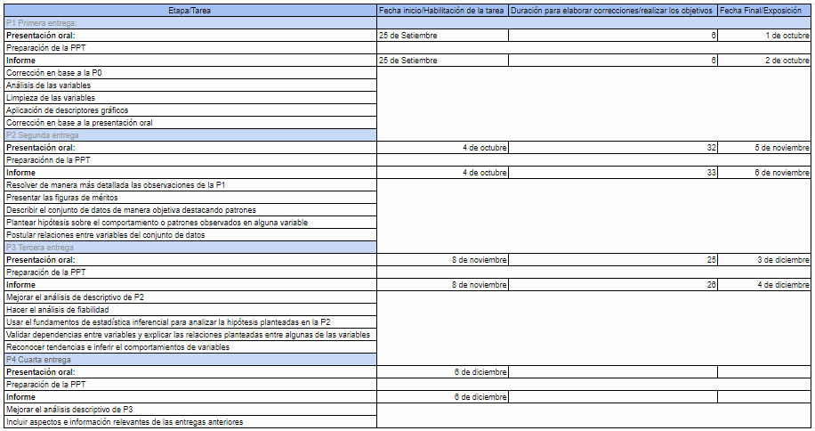

Además, se elaboró un diagrama de Gantt, en el cual se muestra de manera gráfica las fechas de inicio a fin y las duraciones de las entregas de la tabla anterior.

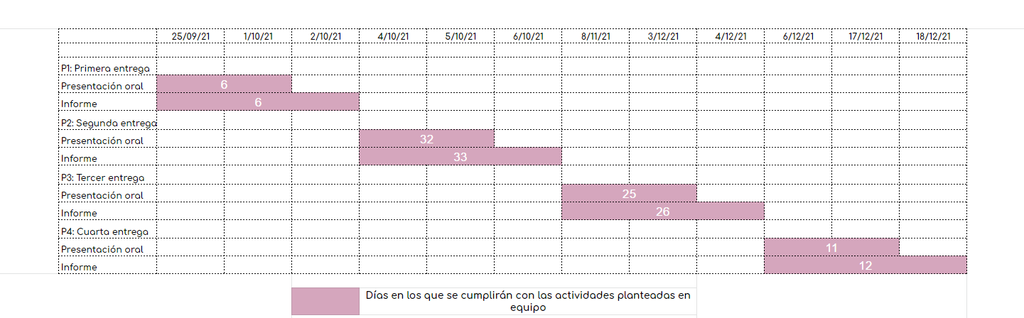

### Marco Teórico

Nuestro estudio se realizará con la ayuda de una encuesta para los usuarios “Óyeme””, es una red profesional que brinda servicios gratuitos de bienestar emocional de manera virtual y personalizada a personas mayores de 18 años. Impulsado por la organización juvenil SUC Social Impact respaldada por la SENAJU (Secretaría Nacional de Juventud).

#### Población Objetivo

1. La población bajo estudio está constituida por adultos mayores de 18 años que acuden a consulta en la organización “Oyeme”.

#### Unidad muestral

2. Paciente de “Óyeme” mayor de 18 años

### Variables y su definición

#### **Numéricas (16)**

##### **Continuas (4)**

| **Variable** | **Definición** | **Restricciones** |
| --- | --- | --- |
| Peso | Peso de los usuarios de “Óyeme” | Mayor igual a 20 kg menor o igual a 197 kg |
| Talla | Talla de los usuarios de “Óyeme” | Mayor igual a 0 cm y menor igual a 2.5 m |
| Tcitas | Tiempo total de citas que tuvieron los usuarios en “Óyeme” | Mayor igual a 0 minutos y menor igual a 24 horas |
| Twebinars | Tiempo total en que los usuarios de “Óyeme” asistieron a los Webinar | Mayor igual a 0 minutos y menor igual a 24 horas |

##### **Discretas (12)**

| **Variable** | **Definición** | **Restricciones** |
| --- | --- | --- |
| Edad | Edad de los usuarios de “Óyeme” | Entero mayor a 18 años |
| Htrabajo | Horas de trabajo a la semana | Opciones desde: 20,30,40,50 a 50+ horas de trabajo |
| Hestudio | Horas que dedican al estudio a la semana | Opciones desde: 20,30,40,50 a 50+ horas de estudios |
| Hdescanso | Horas que duermen los usuarios a la semana | Opciones desde: 20,30,40,50 a 50+ horas de descanso |
| Hlibre | Horas de tiempo libre a la semana | Opciones desde: 20, 30, 40, 50, 50+ horas de tiempo libre |
| Ingreso | Nivel de ingresos totales de los usuarios al mes | Opciones: Menos de 930, 930-1500, 1500-3500, 3500-más, No tiene ingresos |
| Pconvives | Cantidad de las personas con quienes conviven los usuarios | Opciones: 1, 2, 3, 4, 5+ |
| Citas | Número de citas en “Óyeme” | Opciones: 0, 1, 2, 3, 4+ |
| Webinars | Cantidad de Webinars que asistieron los usuarios de “Óyeme” | Opciones: ¿A cuántos Webinars asististe?: 0, 1, 2, 3+ |
| Dcomida | Cantidad de veces que comen al día los usuarios de Óyeme | Opciones: 0, 1, 2, 3, 4+ |
| Animales | Cantidad de animales que tienen los usuarios de Óyeme | Opciones: 0, 1, 2, 3, 4+ |
| Situaciones | Cantidad de veces que los Usuarios tienen estres/ansiedad/depresión/dolores de cabeza | Opciones: 0, 1, 2, 3, 4+ |

#### **Categóricas (10)**

##### **Ordinales(3)**

| **Variable** | **Definición** | **Restricciones** |
| --- | --- | --- |
| Pservicio | Puntaje al servicio que los usuarios le ponen a “Óyeme” | (Menor a Mayor valoración) Opciones: 1, 2, 3, 4 y 5 |
| Pwebinars | Puntaje que le pusieron los usuarios a los webinars de “Óyeme” | (Menor a Mayor valoración) Opciones: 1, 2, 3, 4 y 5 |
| Saludf | Calificación de la salud fisica de los usuarios de Óyeme | (Menor a Mayor valoración) Opciones: 1, 2, 3, 4 y 5 |

##### **Nominales(7)**

| **Variable** | **Definición** | **Restricciones** |
| --- | --- | --- |
| Sexo | Sexo de los usuarios de “Óyeme” | Masculino, Femenino, Prefiero no decirlo |
| Ecivil | Estado civil de los usuarios de “Óyeme” | Soltero, Casado, Divorciado |
| Ocupacion | Ocupación de los usuarios de “Óyeme” | Estudiante, Trabajador, Ambos, Ninguno |
| Canales | Medio por donde conoció “Óyeme” | Opciones: Redes sociales, Por algún conocido(boca a boca), Otro medio |
| Hijos | Si el usuario posee hijos o no | Opciones: Sí, No |
| CentroSalud | Si el usuario vive cerca al centro de salud | Opciones: Sí, No |
| SNAnimales | Si el usuario tiene animales en su hogar | Opciones: Sí, No |

### Limpieza de Data Frame

#### Consideraciones para selección de las variables

Las consideraciones establecidas fueron:

- Información sin sentido
- Claridad de la información

#### Cargando las librerías

```r
library(readr)
library(dplyr)
library(modeest)
library(ggplot2)
library(tidyr)
library(Rlab)
```

#### Cargando el DF

```r
DF <- read_csv("DatosOyeme.csv")
names(DF)
```

```
##  [1] "Marca temporal"
##  [2] "Sexo"
##  [3] "Edad (Número entero mayor a 18 años)"
##  [4] "Ocupación"
##  [5] "Nivel de Ingresos"
##  [6] "Estado civil"
##  [7] "Talla en metros  (Ejm: 1.61 )"
##  [8] "Peso en Kilogramos (Ejm: 49.6)"
##  [9] "¿Cómo conociste a \"Óyeme\"?"
## [10] "¿A cuántas citas asististe en  \"Óyeme\"?"
## [11] "¿Cuánto tiempo total de citas has tenido? Si es 1 cita son 45 min, si son 2 citas son 90 min, etc"
## [12] "¿Qué puntaje le pones al servicio de \"Óyeme\"?"
## [13] "¿A cuántos webinars asististe?"
## [14] "¿Cuánto tiempo total asististe a webinars? Si es 1 webinar son 45 min, si son 2 webinars son 90 min, etc"
## [15] "¿Qué puntaje le pones a los webinars de \"Óyeme\"?"
## [16] "¿Cuántas horas le dedicas a tu trabajo a lo largo de la semana? (aproximadamente) Si no trabajas coloca 0"
## [17] "¿Cuántas horas le dedicas a tu estudio a la semana? (aproximadamente) Si no estudias coloca 0"
## [18] "Condición familiar (hijos o no)"
## [19] "¿Cuántas horas duermes a la semana? (aproximadamente)"
## [20] "¿Cuántas horas tienes de tiempo libre a la semana?"
## [21] "¿Con cuántas personas convives?"
## [22] "¿Cuántas veces a la semana tienes estrés/ ansiedad/ depresión/ dolores de cabeza ?"
## [23] "¿Cómo calificarías tu salud física?"
## [24] "¿Cuántas veces comes al día?"
## [25] "¿Tienes animales en casa?"
## [26] "¿Cuántos animales tienes? Si no tienes coloca 0"
## [27] "¿Tienes cerca de tu hogar un centro de salud?"
```

#### Eliminamos la primera columna y configuramos los nombres de nuestras variables

```r
DFF <- DF[,-1]
DFF %>% rename(Ingreso = `Nivel de Ingresos`, Talla = `Talla en metros  (Ejm: 1.61 )`, Peso = `Peso en Kilogramos (Ejm: 49.6)`, Canales = `¿Cómo conociste a \"Óyeme\"?`, Citas = `¿A cuántas citas asististe en  \"Óyeme\"?`, Pservicio = `¿Qué puntaje le pones al servicio de \"Óyeme\"?`, Tcitas = `¿Cuánto tiempo total de citas has tenido? Si es 1 cita son 45 min, si son 2 citas son 90 min, etc`, Webinars = `¿A cuántos webinars asististe?`, Twebinars = `¿Cuánto tiempo total asististe a webinars? Si es 1 webinar son 45 min, si son 2 webinars son 90 min, etc`, Pwebinars = `¿Qué puntaje le pones a los webinars de \"Óyeme\"?`, Hestudio = `¿Cuántas horas le dedicas a tu estudio a la semana? (aproximadamente) Si no estudias coloca 0`, Hdescanso = `¿Cuántas horas duermes a la semana? (aproximadamente)`, Hlibre = `¿Cuántas horas tienes de tiempo libre a la semana?`, Pconvives = `¿Con cuántas personas convives?`, Situaciones = `¿Cuántas veces a la semana tienes estrés/ ansiedad/ depresión/ dolores de cabeza ?`, Saludf = `¿Cómo calificarías tu salud física?`, Ocupacion = `Ocupación`, Ecivil = `Estado civil`, Hijos = `Condición familiar (hijos o no)`, Edad = `Edad (Número entero mayor a 18 años)`, Htrabajo = `¿Cuántas horas le dedicas a tu trabajo a lo largo de la semana? (aproximadamente) Si no trabajas coloca 0`, Edad = `Edad (Número entero mayor a 18 años)`, CentroSalud = `¿Tienes cerca de tu hogar un centro de salud?`,SNAnimales=`¿Tienes animales en casa?` ,Animales = `¿Cuántos animales tienes? Si no tienes coloca 0`, Dcomida = `¿Cuántas veces comes al día?`) -> DFN
```

```r
DFN$Tcitas[DFN$Tcitas == "45 min"] <- 45
DFN$Tcitas[DFN$Tcitas == "90 min"] <- 90
DFN$Tcitas[DFN$Tcitas == "135 min"] <- 135
DFN$Tcitas<- as.numeric(DFN$Tcitas)
DFN$Twebinars[DFN$Twebinars == "45 min"] <- 45
DFN$Twebinars[DFN$Twebinars == "90 min"] <- 90
DFN$Twebinars[DFN$Twebinars == "135 min"] <- 135
DFN$Twebinars<- as.numeric(DFN$Twebinars)
```

Resumen del DataFrame nuevo

```r
summary(DFN)
```

```
##      Sexo                Edad        Ocupacion           Ingreso
##  Length:151         Min.   :18.00   Length:151         Length:151
##  Class :character   1st Qu.:20.00   Class :character   Class :character
##  Mode  :character   Median :22.00   Mode  :character   Mode  :character
##                     Mean   :22.65
##                     3rd Qu.:24.00
##                     Max.   :44.00
##
##     Ecivil              Talla            Peso        Canales
##  Length:151         Min.   :1.490   Min.   :40.6   Length:151
##  Class :character   1st Qu.:1.580   1st Qu.:54.8   Class :character
##  Mode  :character   Median :1.600   Median :58.5   Mode  :character
##                     Mean   :1.618   Mean   :58.6
##                     3rd Qu.:1.655   3rd Qu.:62.8
##                     Max.   :1.720   Max.   :70.5
##
##      Citas           Tcitas         Pservicio        Webinars
##  Min.   :1.000   Min.   : 45.00   Min.   :3.000   Min.   :1.000
##  1st Qu.:1.000   1st Qu.: 45.00   1st Qu.:4.000   1st Qu.:1.000
##  Median :2.000   Median : 90.00   Median :4.000   Median :1.000
##  Mean   :1.781   Mean   : 77.76   Mean   :4.331   Mean   :1.377
##  3rd Qu.:2.000   3rd Qu.: 90.00   3rd Qu.:5.000   3rd Qu.:2.000
##  Max.   :4.000   Max.   :135.00   Max.   :5.000   Max.   :3.000
##                  NA's   :4
##    Twebinars        Pwebinars        Htrabajo        Hestudio
##  Min.   : 45.00   Min.   :2.000   Min.   : 0.00   Min.   : 0.00
##  1st Qu.: 45.00   1st Qu.:3.000   1st Qu.: 0.00   1st Qu.:30.00
##  Median : 45.00   Median :4.000   Median : 0.00   Median :50.00
##  Mean   : 61.99   Mean   :4.106   Mean   :19.27   Mean   :41.13
##  3rd Qu.: 90.00   3rd Qu.:5.000   3rd Qu.:50.00   3rd Qu.:50.00
##  Max.   :135.00   Max.   :5.000   Max.   :60.00   Max.   :60.00
##
##     Hijos             Hdescanso         Hlibre        Pconvives
##  Length:151         Min.   :30.00   Min.   : 0.00   Min.   :0.000
##  Class :character   1st Qu.:40.00   1st Qu.:30.00   1st Qu.:2.000
##  Mode  :character   Median :50.00   Median :40.00   Median :3.000
##                     Mean   :44.87   Mean   :36.42   Mean   :2.629
##                     3rd Qu.:50.00   3rd Qu.:40.00   3rd Qu.:3.000
##                     Max.   :60.00   Max.   :60.00   Max.   :7.000
##
##   Situaciones        Saludf         Dcomida       SNAnimales
##  Min.   :2.000   Min.   :1.000   Min.   :2.000   Length:151
##  1st Qu.:3.000   1st Qu.:3.000   1st Qu.:3.000   Class :character
##  Median :3.000   Median :3.000   Median :3.000   Mode  :character
##  Mean   :3.457   Mean   :3.099   Mean   :3.457
##  3rd Qu.:4.000   3rd Qu.:4.000   3rd Qu.:4.000
##  Max.   :7.000   Max.   :5.000   Max.   :6.000
##
##     Animales     CentroSalud
##  Min.   :0.000   Length:151
##  1st Qu.:0.000   Class :character
##  Median :1.000   Mode  :character
##  Mean   :1.185
##  3rd Qu.:2.000
##  Max.   :4.000
##
```

```r
DFN
```

```
## # A tibble: 151 x 26
##    Sexo           Edad Ocupacion Ingreso Ecivil Talla  Peso Canales Citas Tcitas
##    <chr>         <dbl> <chr>     <chr>   <chr>  <dbl> <dbl> <chr>   <dbl>  <dbl>
##  1 Femenino         23 Estudian~ No ten~ Solte~  1.56  50.5 Redes ~     1     45
##  2 Masculino        20 Estudian~ No ten~ Solte~  1.7   68.2 Redes ~     2     90
##  3 Prefiero no ~    19 Estudian~ No ten~ Solte~  1.6   58.6 Redes ~     1     45
##  4 Femenino         20 Estudian~ No ten~ Solte~  1.58  55.3 Redes ~     2     90
##  5 Femenino         25 Estudian~ 930 a ~ Solte~  1.65  58.6 Por al~     1     45
##  6 Femenino         22 Estudian~ No ten~ Solte~  1.6   55.5 Redes ~     1     45
##  7 Femenino         25 Estudian~ No ten~ Solte~  1.54  57.3 Redes ~     1     45
##  8 Masculino        24 Estudian~ 930 a ~ Casad~  1.72  66.5 Por al~     1     45
##  9 Femenino         20 Estudian~ No ten~ Solte~  1.59  54.3 Redes ~     2     90
## 10 Masculino        22 Estudian~ Menos ~ Solte~  1.66  59.2 Redes ~     2     90
## # i 141 more rows
## # i 16 more variables: Pservicio <dbl>, Webinars <dbl>, Twebinars <dbl>,
## #   Pwebinars <dbl>, Htrabajo <dbl>, Hestudio <dbl>, Hijos <chr>,
## #   Hdescanso <dbl>, Hlibre <dbl>, Pconvives <dbl>, Situaciones <dbl>,
## #   Saludf <dbl>, Dcomida <dbl>, SNAnimales <chr>, Animales <dbl>,
## #   CentroSalud <chr>
```

### Variables de estudio

Mostraremos cuáles son los números de observaciones y de variables

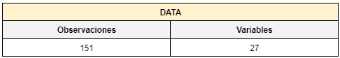

#### Tabla de descriptores numéricos

| **Variable** | **Moda** | **Media** | **Mediana** | **IQR** | **Mínimo** | **Máximo** | **Rango** | **Coeficiente Variación** | **Varianza** | **Desviación Estándar** |  |  |  |  |
| --- | --- | --- | --- | --- | --- | --- | --- | --- | --- | --- | --- | --- | --- | --- |
| Edad | 20 | 22.65 | 22 | 4 | 18 | 44 | 26 | 0.14 | 10.74 | 3.28 |  |  |  |  |
| Talla | 1.6 | 1.62 | 1.6 | 0.075 | 1.49 | 1.72 | 0.23 | 0.03 | 0 | 0.06 |  |  |  |  |
| Peso | 50.5 | 58.6 | 58.5 | 8 | 40.6 | 70.5 | 29.9 | 0.1 | 37.79 | 6.15 |  |  |  |  |
| Pconvives | 2 | 2.63 | 3 | 1 | 0 | 7 | 7 | 0.38 | 1.01 | 1 |  |  |  |  |
| Hdescanso | 50 | 44.87 | 50 | 10 | 30 | 60 | 30 | 0.14 | 38.32 | 6.19 |  |  |  |  |
| Hlibre | 40 | 36.42 | 40 | 10 | 0 | 60 | 60 | 0.37 | 181.79 | 13.48 |  |  |  |  |
| Hestudio | 50 | 41.13 | 50 | 20 | 0 | 60 | 60 | 0.46 | 359.39 | 18.96 |  |  |  |  |
| Htrabajo | 0 | 19.27 | 0 | 50 | 0 | 60 | 60 | 1.3 | 625.47 | 25.01 |  |  |  |  |
| Citas | 1 | 1.78 | 2 | 1 | 1 | 4 | 3 | 0.44 | 0.63 | 0.79 |  |  |  |  |
| Webinars | 1 | 1.38 | 1 | 1 | 1 | 3 | 2 | 0.43 | 0.36 | 0.6 |  |  |  |  |
| Animales | 1 | 1.19 | 1 | 2 | 0 | 4 | 4 | 0.86 | 1.05 | 1.02 |  |  |  |  |
| Situaciones | 3 | 3.46 | 3 | 1 | 2 | 7 | 5 | 0.2 | 0.46 | 0.68 |  |  |  |  |

### Análisis de las variables

[output not shown]

### Preguntas con Hipótesis

[output not shown]

### Descriptores gráficos de variables cuantitativas

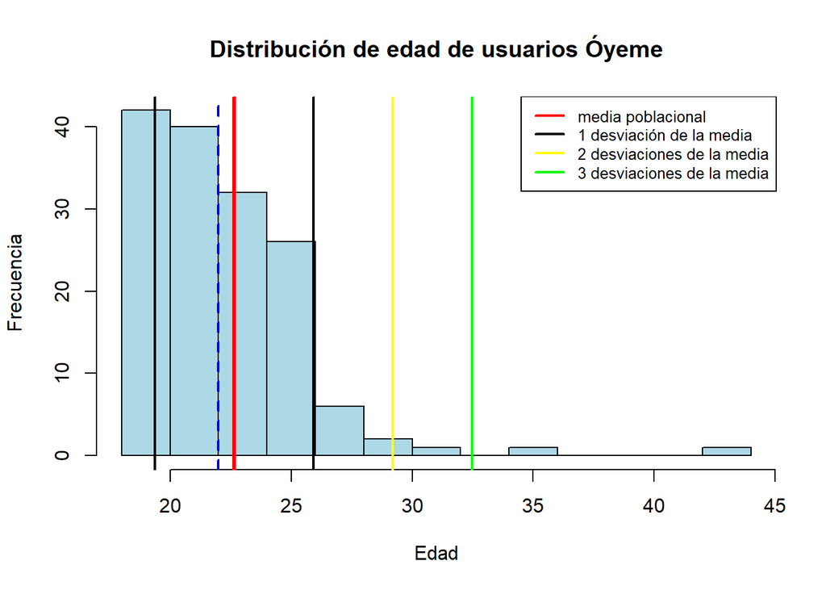

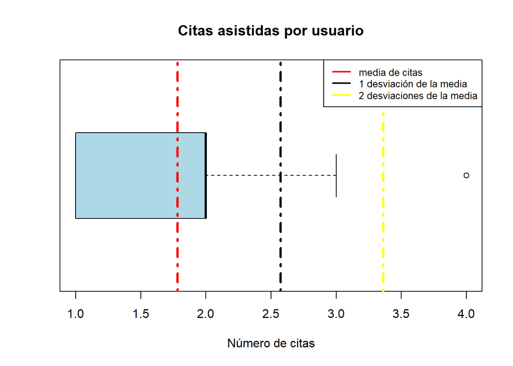

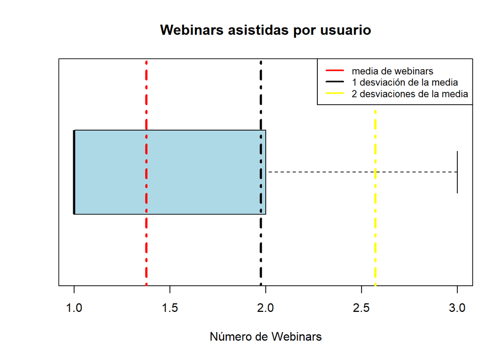

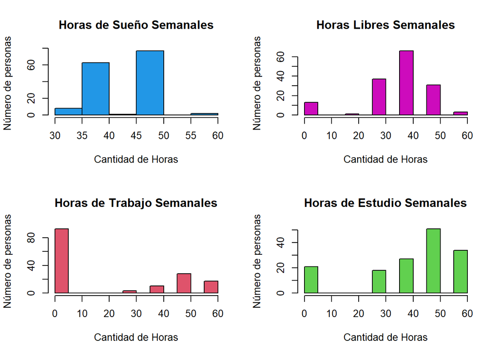

La mayor cantidad de encuestados le dedica más tiempo a las horas de sueño y/o estudio mientras que le dedican menos horas al trabajo a la semana. Esto se debe principalmente a que muchas de las personas encuestadas posiblemente no trabajan, ya que colocaron 0 horas de trabajo a la semana. Por otro lado, se observa cómo los usuarios de “Óyeme” suelen dedicarle más horas a la semana de estudio y a las horas libres.

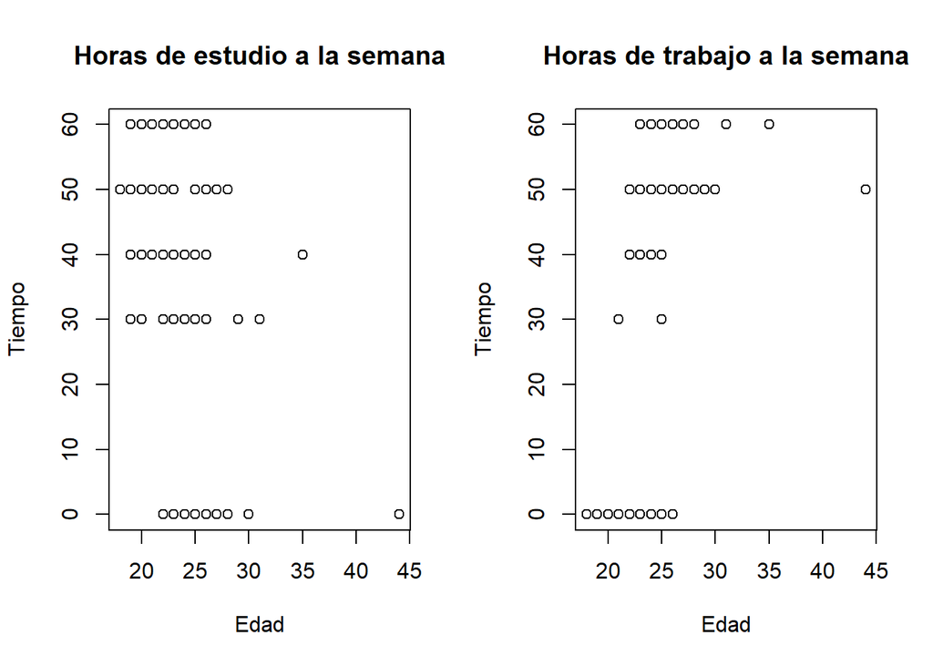

```r
op <- par(mfrow = c(1,2))
plot(DFN$Hestudio~DFN$Edad,main = "Horas de estudio a la semana" ,xlab = "Edad", ylab = "Tiempo")
plot(DFN$Htrabajo~DFN$Edad,main = "Horas de trabajo a la semana" ,xlab = "Edad", ylab = "Tiempo")
```

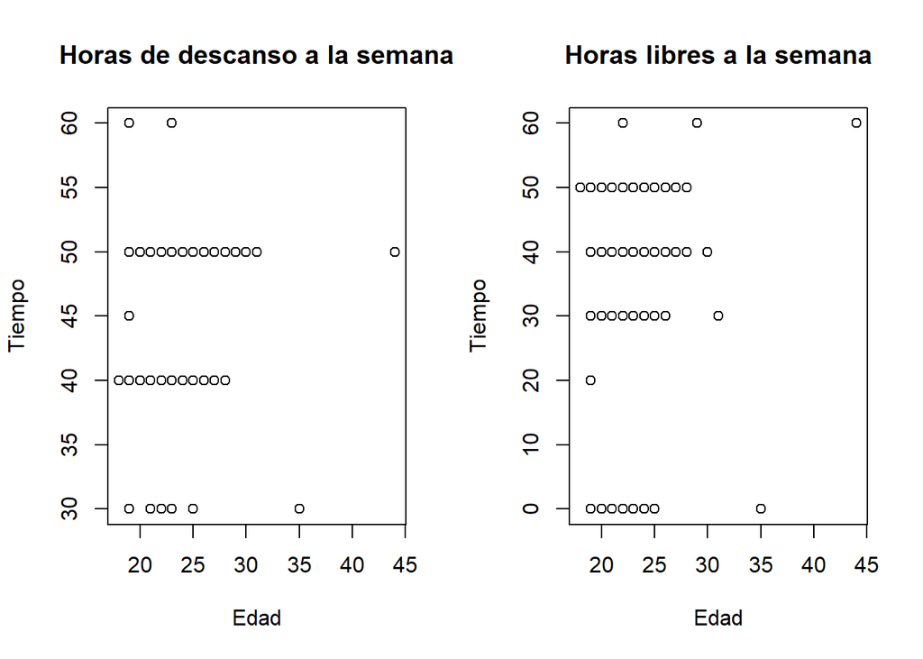

```r
op <- par(mfrow = c(1,2))
plot(DFN$Hdescanso~DFN$Edad,main = "Horas de descanso a la semana" ,xlab = "Edad", ylab = "Tiempo")
plot(DFN$Hlibre~DFN$Edad,main = "Horas libres a la semana" ,xlab = "Edad", ylab = "Tiempo")
```

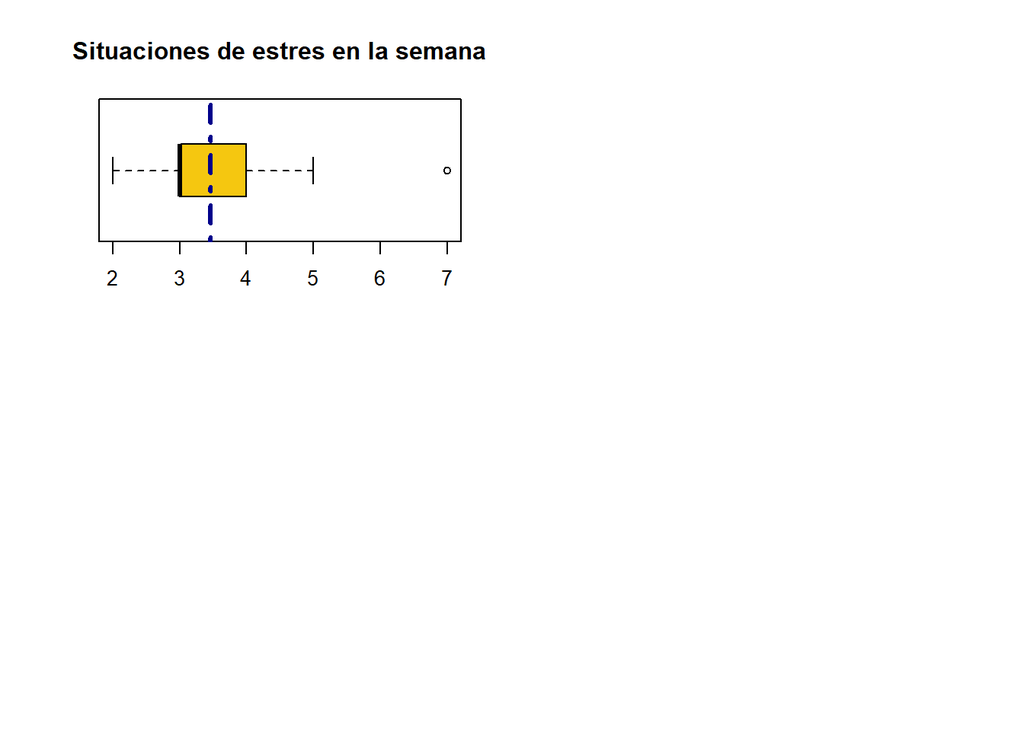

En la gráfica de los datos de “Situaciones de estrés en la semana” la moda son 3. Podemos observar que el mínimo es 2 y el máximo es 7.La moda es una cantidad moderada de veces que un usuario de Óyeme tiene estrés, esto se puede deber a diversos factores que se le presentan en su vida diaria.

### Descriptores gráficos de Variables Cualitativas

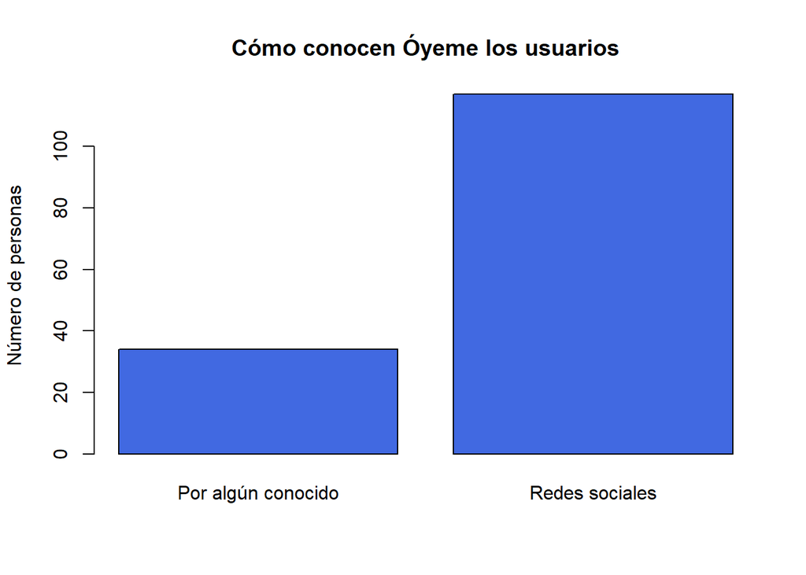

Podemos observar en la gráfica que la mayoría de los usuarios conocen a “Óyeme” por medio de las redes sociales. Esto puede ser debido a que más del 60% son jóvenes de entre 18 a 26 años y son los que mayormente utilizan distintas aplicaciones para investigar sobre algún tema, organización, empresa entre otros. Por otro lado, menos de 40 personas conocen a “Óyeme” por medio de algún conocido cabe mencionar que puede ser debido a que estamos en pandemia lo que nos lleva a no poder estar en constante contacto con nuestros familiares, amigos y conocidos.

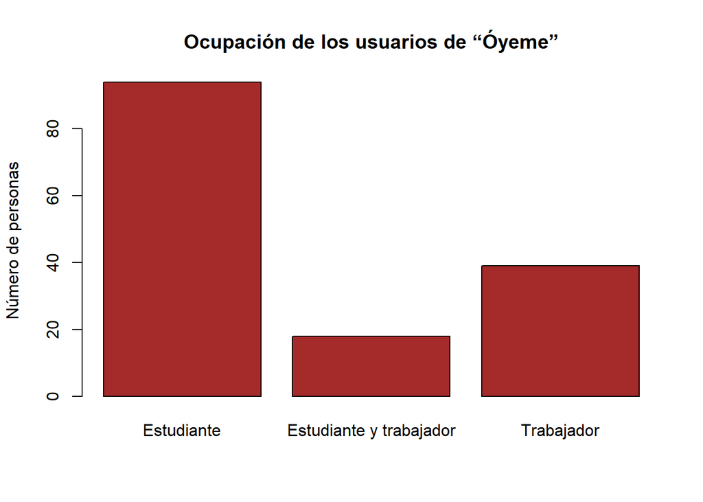

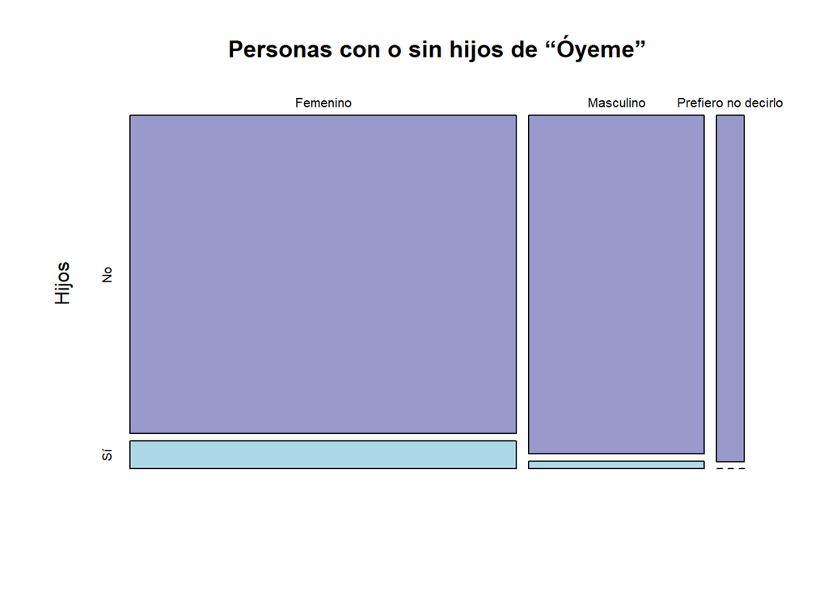

En la gráfica podemos observar una representación unida entre el género de los usuarios y si tienen hijos. Más del 50% de los usuarios no tiene hijos y podemos concluir que la razón es porque la mayoría de los usuarios son gente joven ya sea estudiantes o universitarios. Además, nos damos cuenta que las mujeres son las que sí tienen hijos en un bajo porcentaje a comparación de los hombres que es casi nula y que las personas que no quisieron decir su género no tienen hijos.

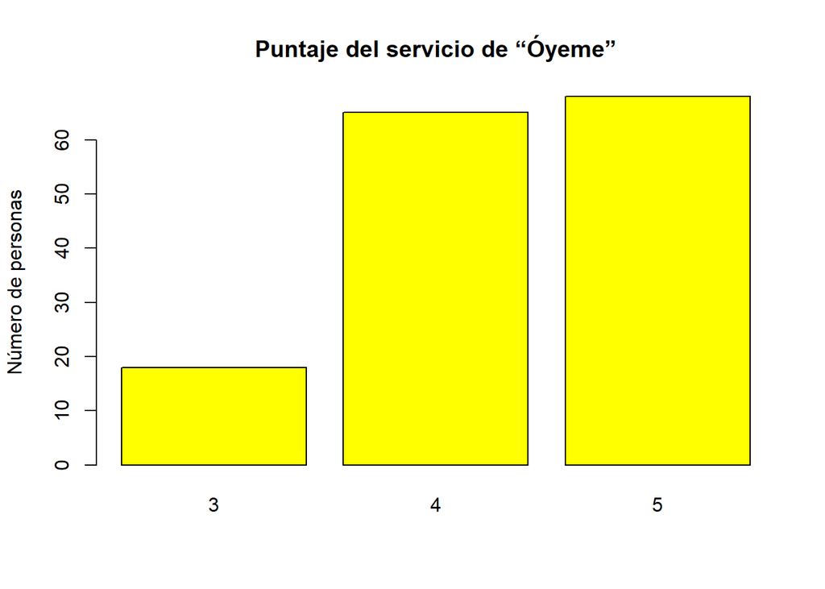

Podemos observar en la gráfica que la gran mayoría de los usuarios de “Óyeme” se sienten satisfechos con el servicio que brinda, más del 50% lo califica entre 4 y 5 estrellas. Además, no existe puntaje bajo simplemente intermedio lo que nos da a conocer que la organización, la atención y calidad en su gran mayoría es muy buena.

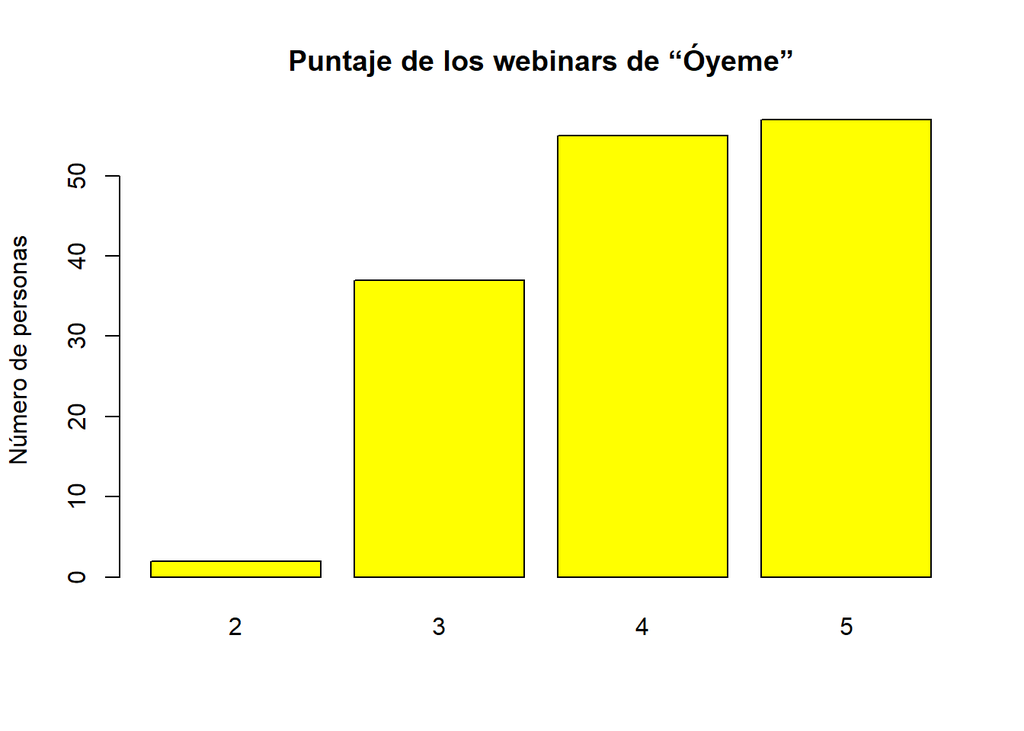

En esta gráfica podemos observar que un alto número de los usuarios de “Óyeme” se sienten satisfechos con los webinars que se organizan, más del 50% lo califica 3 y 4 estrellas. Se observa también que hay un bajo número de personas que lo calificaron con 2, lo cual nos da a entender que no se sintieron lo suficientemente satisfechos con los webinars.

### Patrones

Variables relacionadas

- Relación entre la variable Sexo y Edad
- Relación entre variable Sexo e Hijos
- Relación entre variables Edad y Ocupación
- Relación entre variables Edad e Ingresos
- Relación entre variables Ocupación y Horas libres

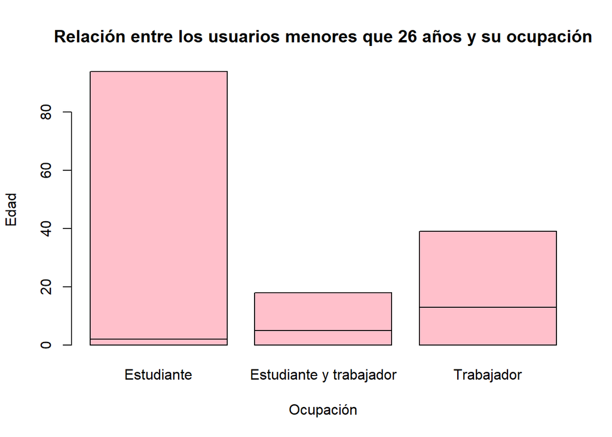

```r
barplot(table(DFN$Edad<26,DFN$Ocupacion),main = "Relación entre los usuarios menores que 26 años y su ocupación" ,xlab = "Ocupación", ylab = "Edad", col = c("pink"))
```

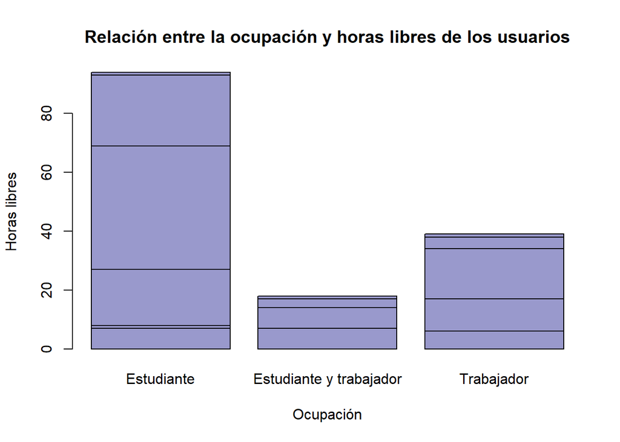

```r
barplot(table(DFN$Hlibre,DFN$Ocupacion),main = "Relación entre la ocupación y horas libres de los usuarios" ,xlab = "Ocupación", ylab = "Horas libres", col = c("#9999cc"))
```

Análisis: En esta gráfica podemos observar que hay una tendencia en los usuarios de Óyeme, esta es que mayormente los que estudian y trabajan tienen menos horas libres, esto puede ser debido a que tienen que estudiar y hacer sus trabajos pendientes.

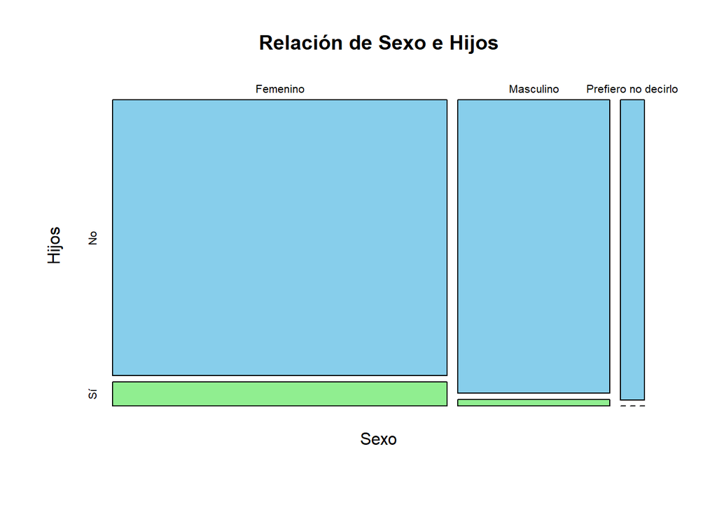

```r
mosaicplot(table(DFN$Sexo,DFN$Hijos),main = "Relación de Sexo e Hijos" ,xlab = "Sexo", ylab = "Hijos", col = c("skyblue", "lightgreen") )
```

Análisis: En esta gráfica podemos observar una tendencia que tienen los usuarios de Óyeme, esta es que mayormente los usuarios no tienen hijos. Por otro lado, también se observa que quienes tienen hijos en su mayoría son las mujeres comparado con los varones.

### Variables aleatorias

#### Binomial

##### Edad

```r
table(DFN$Edad)
```

```
##
## 18 19 20 21 22 23 24 25 26 27 28 29 30 31 35 44
##  1 18 23 20 20 20 12 17  9  4  2  1  1  1  1  1
```

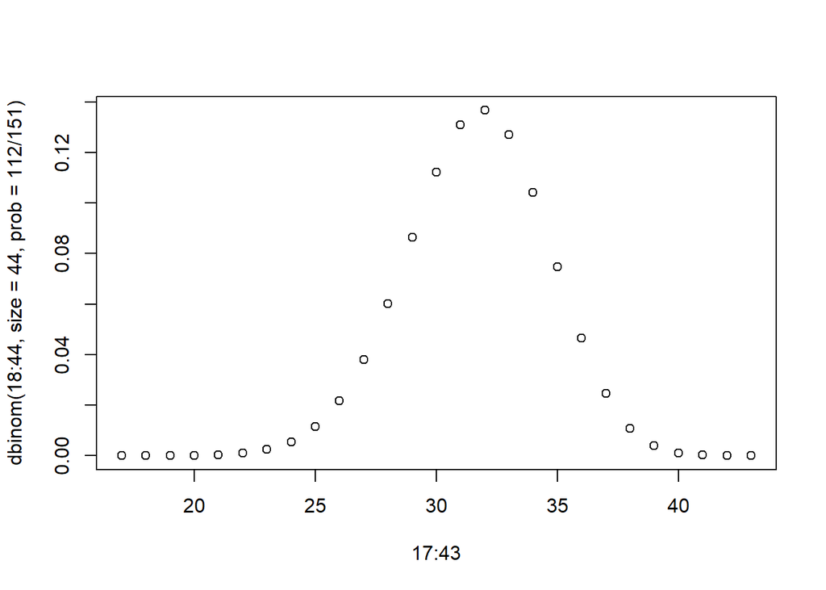

```r
plot(17:43,dbinom(18:44, size = 44, prob =112/151 ))
```

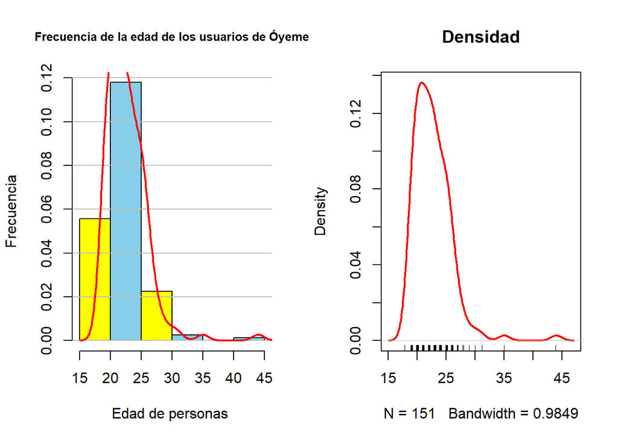

```r
x <- DFN$Edad

op <- par(mfrow = c(1,2))
# Creamos un histograma
hist(x, freq = FALSE,main="Frecuencia de la edad de los usuarios de Óyeme",cex.main=0.8, col=c("yellow","skyblue"), xlab="Edad de personas ",ylab="Frecuencia")
grid(nx = NA, ny = NULL, lwd = 1, lty = 1, col = "gray")


# Calculamos la densidad
dx <- density(x)

# Añadimos la línea de densidad
lines(dx, lwd = 2, col = "red")

# Curva de densidad sin histograma
plot(dx, lwd = 2, col = "red",
     main = "Densidad")

# Añadimos los datos con riudo en el eje X
rug(jitter(x))
```